# Chicken Weights: Portfolio Report 1

Ahmed Almohammed

> A report to analyze the chicken weights dataset.

We will start by initializing the packages required in this report.

## Part I: General understanding of the dataset

The dataset contains the following variables:

```r
ChickWeight
```

|  | weight | Time | Chick | Diet |
| --- | --- | --- | --- | --- |
| 1 | 42 | 0 | 1 | 1 |
| 2 | 51 | 2 | 1 | 1 |
| 3 | 59 | 4 | 1 | 1 |
| 4 | 64 | 6 | 1 | 1 |
| 5 | 76 | 8 | 1 | 1 |
| 6 | 93 | 10 | 1 | 1 |
| 7 | 106 | 12 | 1 | 1 |
| 8 | 125 | 14 | 1 | 1 |
| 9 | 149 | 16 | 1 | 1 |
| 10 | 171 | 18 | 1 | 1 |

[output cut: 568 more lines]

Here is a random sample of the data set

```r
set.seed(1234)
ChickWeight %>%
    slice(sample(1:nrow(.), 10, replace = FALSE)) %>%
    knitr::kable()
```

| weight | Time | Chick | Diet |
| --- | --- | --- | --- |
| 74 | 6 | 26 | 2 |
| 96 | 10 | 9 | 1 |
| 373 | 21 | 35 | 3 |
| 59 | 4 | 9 | 1 |
| 92 | 14 | 9 | 1 |
| 230 | 18 | 29 | 2 |
| 146 | 12 | 7 | 1 |
| 49 | 2 | 25 | 2 |
| 134 | 10 | 34 | 3 |
| 51 | 2 | 17 | 1 |

```r
ChickWeight %>%
    head(10) %>%
    knitr::kable()
#%>%
 # kable_styling(bootstrap_options = "striped", full_width = F, position = "left")
```

[output not shown]

```r
# view the summary of the dataset
summary(ChickWeight)
```

```
##      weight           Time           Chick     Diet
##  Min.   : 35.0   Min.   : 0.00   13     : 12   1:220
##  1st Qu.: 63.0   1st Qu.: 4.00   9      : 12   2:120
##  Median :103.0   Median :10.00   20     : 12   3:120
##  Mean   :121.8   Mean   :10.72   10     : 12   4:118
##  3rd Qu.:163.8   3rd Qu.:16.00   17     : 12
##  Max.   :373.0   Max.   :21.00   19     : 12
##                                  (Other):506
```

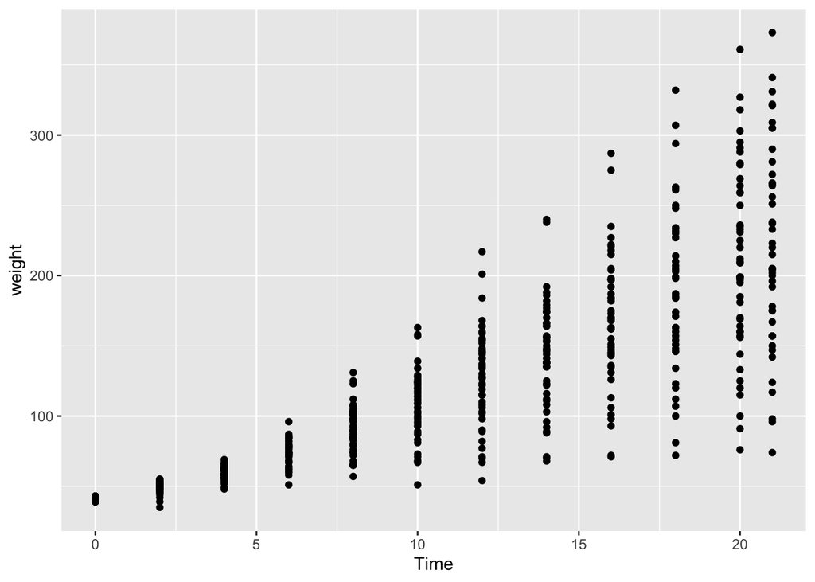

```r
# Plot the dataset to view it (Point Plot)
ggplot(data=ChickWeight, mapping = aes(x=Time, y=weight)) +
    geom_point()
```

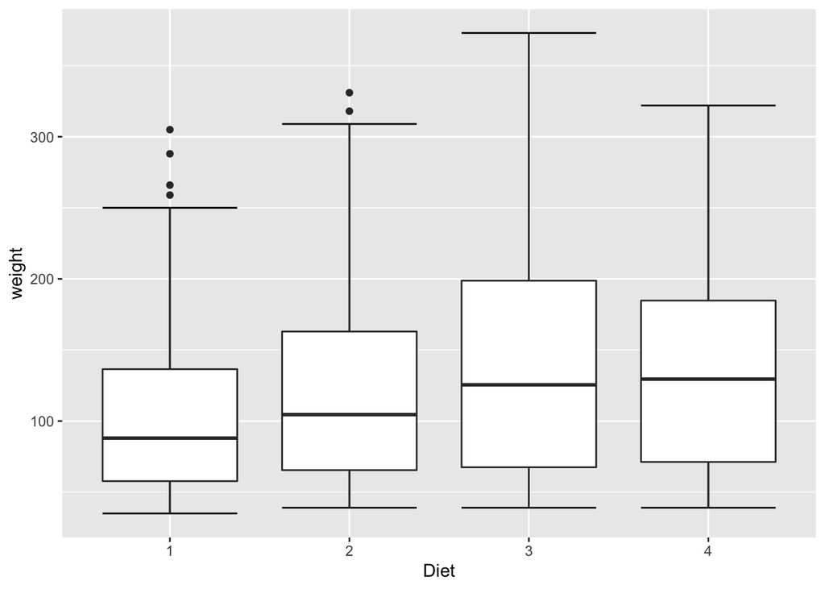

```r
# Plot the dataset to view it (Box Plot)
ggplot(ChickWeight, mapping = aes(x=Diet, y=weight)) +
    stat_boxplot(geom ='errorbar') +
    geom_boxplot()
```

## Part II: Deeper understanding of the dataset

With the above information, we can proceed to exploring the relations between the variables for additional insights.

We will start with grouping the dataset based on the type of `Diet` variable.

```r
# Now, we create a tibble that shows us the details of the chickens
# when grouped by the diet they were fed on
ChickWeight %>% group_by(Diet) %>% summarise(number_of_chicks = n_distinct(Chick))
```

| Diet | number_of_chicks |
| --- | --- |
| 1 | 20 |
| 2 | 10 |
| 3 | 10 |
| 4 | 10 |

We can see that there are 4 types of `Diet` that were tested on a total of 50 `Chick`, with :

- **20 chickens following diet 1**
- **10 chickens following diet 2**
- **10 chickens following diet 3**
- **10 chickens following diet 4**

Now, we group them based on the `Time` variable.

```r
ChickWeight  %>% group_by(Time)  %>% summarise(number_of_chicks = n_distinct(Chick))
```

| Time | number_of_chicks |
| --- | --- |
| 0 | 50 |
| 2 | 50 |
| 4 | 49 |
| 6 | 49 |
| 8 | 49 |
| 10 | 49 |
| 12 | 49 |
| 14 | 48 |
| 16 | 47 |
| 18 | 47 |

[output cut: 2 more lines]

From the above examination, we can see that the `Diet` was for a period of 21 days, where at the start there were the full number of `Chick`, total of 50 `Chick`. However, towards the end, we ended up with 45 `Chick`! We can also notice a positive correlation between time and weight, where the weight of the `chick` tends to increase along the `time` interval.

With this new information, we see that some of the chicks didnt complete the full 21 days, and so we need to clean the data from these 5 `Chick` that did not make it to the 21 day.

```r
# Filter the chicks
filtered  <- as_tibble(ChickWeight  %>% filter(Time == 21))

# View the list of required chicks
chick_list <- filtered$Chick

# Make a new dataset with only the required chicks
ChickWeight  <- as_tibble(ChickWeight)
ChickWeight_filtered  <- subset(ChickWeight, (ChickWeight$Chick %in% chick_list))

# Check the result
ChickWeight_filtered  %>% group_by(Time)  %>% summarise(number_of_chicks = n_distinct(Chick))
```

| Time | number_of_chicks |
| --- | --- |
| 0 | 45 |
| 2 | 45 |
| 4 | 45 |
| 6 | 45 |
| 8 | 45 |
| 10 | 45 |
| 12 | 45 |
| 14 | 45 |
| 16 | 45 |
| 18 | 45 |

[output cut: 2 more lines]

We are now able to contiue through the process of analyzing the dataset as we cleaned it off from the unrequired data of the 5 `Chick` that didnt complete the specified number of days of the `Diet`

We can now plot our filtered dataset. We will start with a box plot.

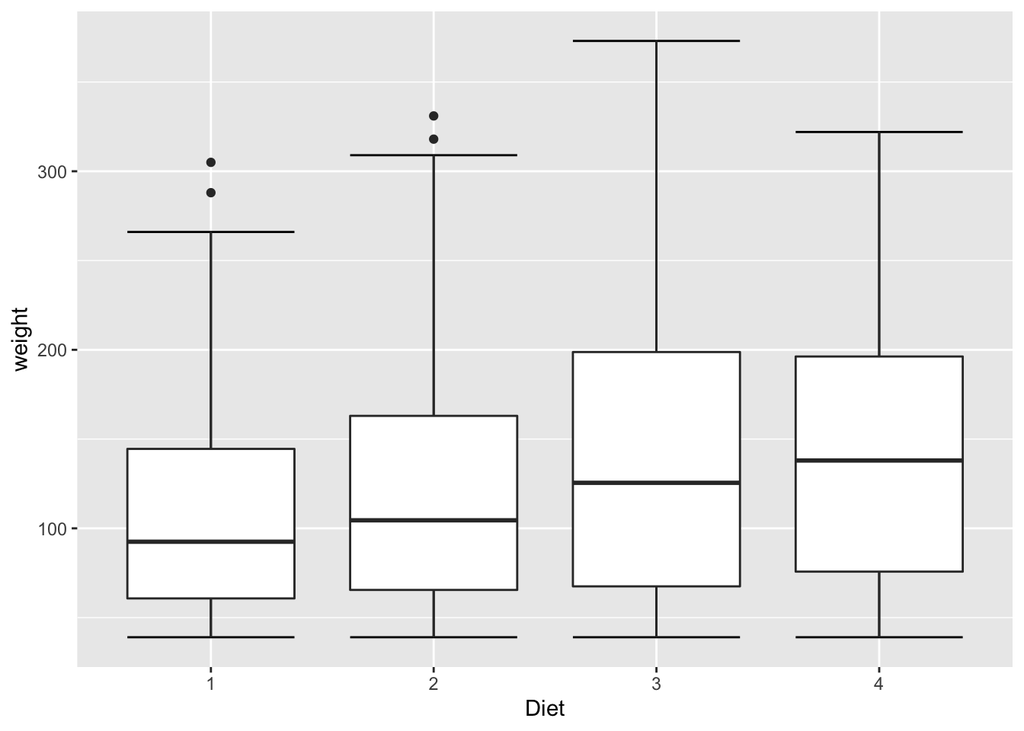

```r
# Plot a boxplot of the data
ggplot(ChickWeight_filtered, mapping = aes(x=Diet, y=weight)) +
    stat_boxplot(geom ='errorbar') +
    geom_boxplot()
```

```r
# Check the highest weight in the diet groups
ChickWeight_filtered  %>% group_by(Diet)  %>% summarise(max_weight = max(weight))
```

| Diet | max_weight |
| --- | --- |
| 1 | 305 |
| 2 | 331 |
| 3 | 373 |
| 4 | 322 |

We notice the following:-

- The median is very low in `Diet1` compared to the other diets.
- Both `Diet3` and `Diet4` have no outliers.
- Both `Diet3` and `Diet4` have a high median value compared to `Diet1` and `Diet2`